# Analysis of Ford GoBike System Data

## by Abishek Shyamsunder

## Investigation Overview

> This presentation aims to provide insights into the dataset described below visually. It aims to answer the questions.
> 1. What is the distribution of rides across the day?
> 2. Are there any differences between the rides of Customers and Subscribers?
> 3. Are there any differences between the rides across the week/ between weekdays and weekends?

## Dataset Overview

> The dataset used here is provided by Bay Area Motivate, LLC ("Motivate"), and it contains bike ride data collected between June 2017 and May 2018  
> The dataset is contains 1,142,896 entries and 20 columns

## (Visualization 1)

> Visualization1 helps us understand the distribution of rides across the day. (i.e. a count was taken for each hour of the day), with the subslide showing the distribution for each user type individually  
> SubSlide 1: The number of rides peaks at 8 in the morning and at 5 in the evening, especially due to Subscribers

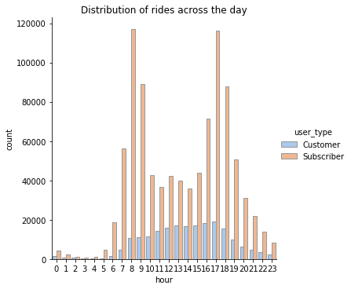

```python
base_color = sb.color_palette()[2]
sb.catplot(x="hour", hue="user_type", kind="count",palette="pastel", edgecolor=".6",data=df);
plt.title('Distribution of rides across the day');
```

## (Visualization 2)

> Visualization 2 helps us understand the differences between the trips of Consumers and Subscribers  
> SubSlide 1: Despite the average distance travelled each month by Subscribers and Customers being almost equal, the average duration of trips for Subscribers is much lesser across the year

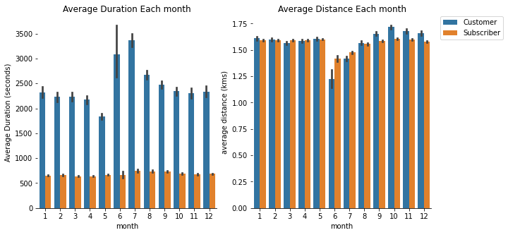

```python
f, axes = plt.subplots(1, 2, figsize=(10, 5), sharex=True)
sb.despine(left=True)

ax = sb.barplot(data = df, x = 'month', y = 'duration_sec', hue="user_type",ax=axes[0]);
plt.ylabel('average duration');
ax.legend_.remove()
ax.set_title('Average Duration Each month')
ax.set_ylabel('Average Duration (seconds)')

ax2 = sb.barplot(data = df, x = 'month', y = 'distance', hue="user_type",ax=axes[1]);
plt.ylabel('average distance (kms)');
ax2.set_title('Average Distance Each month')
plt.legend(bbox_to_anchor=(1.05, 1), loc=2, borderaxespad=0.)
```

## (Visualization 3)

> Helps us understand if there are any differences between the rides in weekdays and weekends  
> SubSlide 1: Despite the average distance being slightly lesser in weekends, the average duration for each trip is much higher  
> SubSlide 2: This trend is seen in both Customers and Subscribers  
> Subslide 3: Total Number of rides in weekends and weekdays compared. Number of rides on weekends is lesser

[figure not shown]

```python
base_color = sb.color_palette()[0]
f, axes = plt.subplots(1, 2, figsize=(15, 5), sharex=True)
sb.despine(left=True)

ax = sb.barplot(data = df, x = 'day', y = 'duration_sec',color = base_color,ax=axes[0]);
ax.set_ylabel('Average Duration (seconds)')
ax.set_title('Average Duration each day')

ax2 = sb.barplot(data = df, x = 'day', y = 'distance',color = base_color,ax=axes[1]);
plt.ylabel('average distance (kms)');
ax2.set_title('Average Distance each day')
```

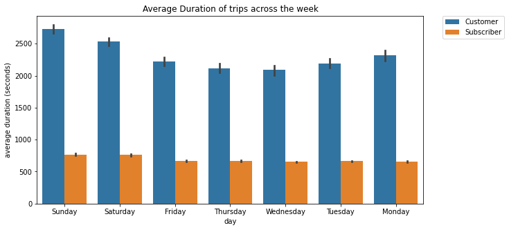

```python
base_color = sb.color_palette()[0]
fig = plt.figure(figsize=(10,5))
sb.barplot(data = df, x = 'day', y = 'duration_sec', hue="user_type");
plt.ylabel('average duration (seconds)');
plt.legend(bbox_to_anchor=(1.05, 1), loc=2, borderaxespad=0.)
plt.title('Average Duration of trips across the week')
```

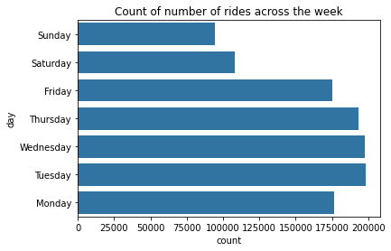

```python
base_color = sb.color_palette()[0]
sb.countplot(data = df,y = 'day',color = base_color)
plt.title('Count of number of rides across the week');
```